# Predicting Weight Lifting Exercise Scenario

Martijn Leunissen

25 October 2015

# Summary

Using devices such as Jawbone Up, Nike FuelBand, and Fitbit it is now possible to collect a large amount of data about personal activity relatively inexpensively. These type of devices are part of the quantified self movement. A group of enthusiasts who take measurements about themselves regularly to improve their health, to find patterns in their behavior, or because they are tech geeks.

One thing that people regularly do is quantify how much of a particular activity they do, but they rarely quantify how well they do it. In this data set, the participants were asked to perform barbell lifts correctly and incorrectly in 5 different ways. For more info see [1].

In this document we will use the data from these sensors to predict the manner in which a participant performed the exercise based on sensor data.

# Setup

## General Setup

```r
#Load libraries and set up random seed
library(randomForest)
library(caret)
library(parallel)
library(doMC)
registerDoMC(cores = 8)
set.seed(42*37)
```

## Obtain Data Set

```r
# Get input files if not available in current working set
training.filename <- './training.csv'
testing.filename <- './testing.csv'
training.url <-'http://d396qusza40orc.cloudfront.net/predmachlearn/pml-training.csv'
testing.url <- 'http://d396qusza40orc.cloudfront.net/predmachlearn/pml-testing.csv'
if (!file.exists(training.filename)) {
    download.file(
      training.url,
      destfile = training.filename
    )
}
if (! file.exists(testing.filename)) {
    download.file(
      testing.url,
      destfile = testing.filename
    )
}

training.raw <- read.csv(training.filename, dec=".", na.strings=c("NA",""), strip.white=T)
testing.raw <- read.csv(testing.filename, dec=".", na.strings=c("NA",""), strip.white=T)
training.raw$nuser_name <- as.factor(training.raw$user_name)
testing.raw$nuser_name <- as.factor(testing.raw$user_name)
```

# Data Set Exploration

Based on the summary of the data (see appendix I) we see that there are a few columns that contain only experimental setup values. Furthermore there are a lot of columns that contain mainly NA values. To obtain a good set of predictors for the model I choose to:

- Remove the experimental setup values
- Remove columns that have a high number of NA’s

Furthermore, after cleaning the data set using the steps above we will:

- Remove columns that have near zero variance
- Remove correlated columns

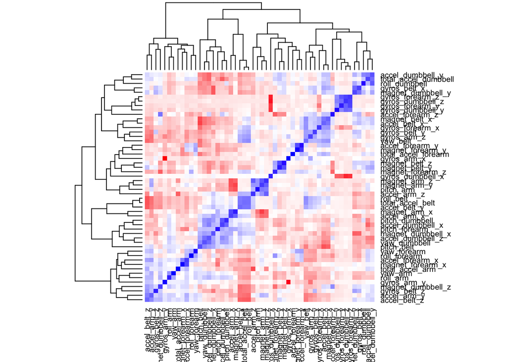

```r
columnConditionFraction <- function(data, condition, fraction){
  res <- apply(data, 2, function(x) { length(which(condition(x)))/length(x) })
  return(res)
}
columnNamesConditionFraction <- function(data, condition, fraction){
  counts <- apply(data, 2, function(x) { length(which(condition(x)))/length(x) })
  res <- colnames(data)[counts >= fraction]
  return(res)
}

columnNumbersConditionFraction <- function(data, condition, fraction){
  res <- which(colnames(data) %in% columnNamesConditionFraction(data, condition, fraction))
  return(res)
}

#Remove Columns that belong to the experimental setup
experimental.setup.columns <- which(colnames(training.raw) %in% c('X', 'raw_timestamp_part_1', 'raw_timestamp_part_2', 'cvtd_timestamp', 'new_window', 'num_window'))
training.noexp <- training.raw[ ,-experimental.setup.columns]

#Remove Columns that consists for more then 5% out of NA values
training.nona <- training.noexp[ ,-columnNumbersConditionFraction(training.noexp, is.na,0.05)]

#Remove Columns that have near zero variation
training.nearZeroVar <- nearZeroVar(training.nona[sapply(training.nona, is.numeric)],saveMetrics=T)
training.noZeroVar <-  training.nona[,training.nearZeroVar[, 'nzv']==F]

#Look into correlation using correlation matrix an plot
training.correlationMatrix <- cor(na.omit(training.noZeroVar[sapply(training.noZeroVar, is.numeric)]))
training.correlationDF <- expand.grid(
  row=1:dim(training.correlationMatrix)[1],
  col=1:dim(training.correlationMatrix)[2]
)

#alternative plot
#training.correlationDF$correlation <- as.vector(training.correlationMatrix)
#levelplot(correlation ~ row+ col, training.correlationDF)

corPalette <- colorRampPalette(c("red", "white", "blue"))(n=1024)
heatmap(training.correlationMatrix, col = corPalette )
```

```r
#Remove Columns with higher than abs 0.9 correlation
training.correlation <- findCorrelation(training.correlationMatrix, cutoff = .9, verbose = TRUE)
```

```
## Compare row 10  and column  1 with corr  0.992
##   Means:  0.27 vs 0.168 so flagging column 10
## Compare row 1  and column  9 with corr  0.925
##   Means:  0.25 vs 0.164 so flagging column 1
## Compare row 9  and column  4 with corr  0.928
##   Means:  0.233 vs 0.161 so flagging column 9
## Compare row 8  and column  2 with corr  0.966
##   Means:  0.245 vs 0.157 so flagging column 8
## Compare row 19  and column  18 with corr  0.918
##   Means:  0.091 vs 0.158 so flagging column 18
## Compare row 46  and column  31 with corr  0.914
##   Means:  0.101 vs 0.161 so flagging column 31
## Compare row 46  and column  33 with corr  0.933
##   Means:  0.083 vs 0.164 so flagging column 33
## All correlations <= 0.9
```

```r
training.clean <- training.noZeroVar[,-training.correlation]
```

# Data Slicing

Split Original Training set in a model training and model testing set

```r
inTrain <- createDataPartition(training.clean$classe, p=0.7, list=F)
model.training <- training.clean[inTrain,]
model.testing <- training.clean[-inTrain,]
```

# Model

In my initial attempt to build a predictive model I chose to use the random forest algorithm.

Random forests have some advantegeous properties that make them a good choice for this high-dimensional classification problem where the number of observations available far exceeds the number of predictors.

- No parameter selection is involved.
- Good in-training measure of variable importance
- Out of bag error can be used as estimate for generalization error

```r
#Train on cleaned dataset using random forest
ctrl <- trainControl(allowParallel=T, method="repeatedcv", number=10, repeats=3)
#ctrl <- trainControl(allowParallel=T, method="repeatedcv", number=2, repeats=1)
model <- train(classe ~ ., data=model.training, model="rf", trControl=ctrl)
pred <- predict(model, newdata=model.testing)
```

## Resulting variable importance as indicated by the model

```r
varImp(model)
```

```
## rf variable importance
##
##   only 20 most important variables shown (out of 51)
##
##                   Overall
## roll_belt          100.00
## yaw_belt            86.32
## magnet_dumbbell_z   72.18
## magnet_dumbbell_y   69.68
## pitch_belt          69.43
## pitch_forearm       65.97
## roll_forearm        59.63
## magnet_dumbbell_x   57.27
## accel_belt_z        55.30
## accel_dumbbell_y    53.49
## roll_dumbbell       52.18
## magnet_belt_z       51.15
## magnet_belt_y       50.20
## accel_dumbbell_z    48.22
## roll_arm            46.48
## accel_dumbbell_x    41.69
## accel_forearm_x     41.66
## magnet_arm_y        39.97
## yaw_dumbbell        38.82
## accel_arm_x         38.36
```

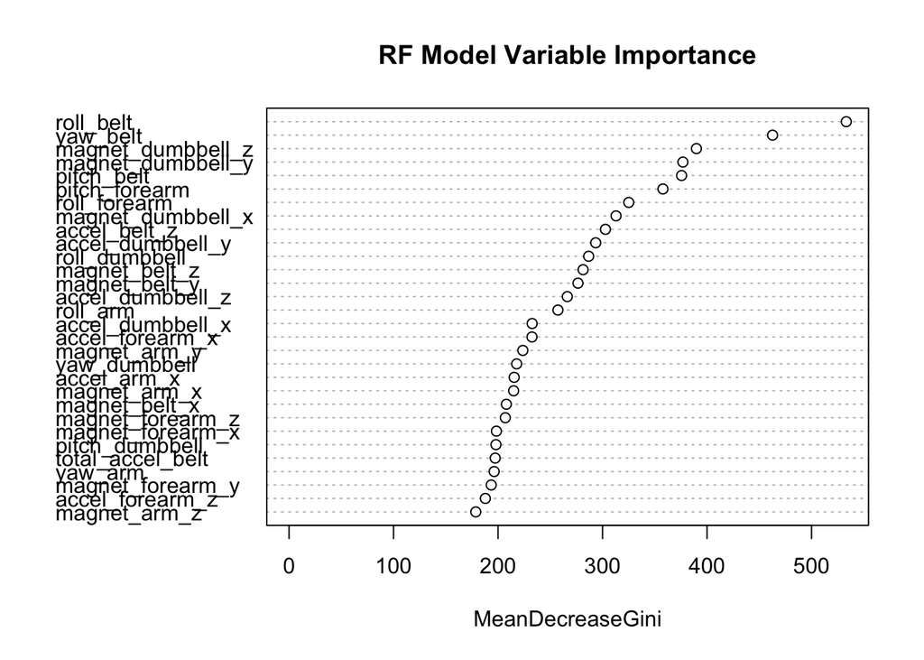

```r
varImpPlot(model$finalModel, main="RF Model Variable Importance")
```

```r
?varImpPlot
```

## Model Validation

We use the test set part of the training set to cross-validate the results:

```r
#The accuraracy of the model is:
accuracy <- sum(pred == model.testing$classe) / length(pred)
accuracy
```

```
## [1] 0.9932031
```

Confusion Matrix and Out of Sample Error:

```r
confusionMatrix <- confusionMatrix(model.testing$classe, pred)$table
confusionMatrix
```

```
##           Reference
## Prediction    A    B    C    D    E
##          A 1673    1    0    0    0
##          B    5 1132    2    0    0
##          C    0    4 1022    0    0
##          D    0    0   21  942    1
##          E    0    0    1    5 1076
```

```r
outOfSampleError <- 1-sum(diag(confusionMatrix))/sum(as.vector(confusionMatrix))
outOfSampleError
```

```
## [1] 0.006796941
```

# Results

Apply model to real testing set to obtain final answers

```r
#Clean testing set similar to trianing set
testing.clean <- testing.raw[,which(colnames(testing.raw) %in% names(training.clean))]
#Apply model
answers <- predict(model, newdata=testing.clean)
answers
```

```
##  [1] B A B A A E D B A A B C B A E E A B B B
## Levels: A B C D E
```

Based on the feedback from the test all of these answers are correct, so the model reached a 100% correct result rate.

# Conclusion

The model obtained using the initial approach has a low out of sample error. It also performed perfectly on the testing set provided. Further exploration of an alternative model does not seem neccessary. Using the Random Forests method we can create a high quality predictive model for the data set provided.

# References

[1] Velloso, E.; Bulling, A.; Gellersen, H.; Ugulino, W.; Fuks, H. Qualitative Activity Recognition of Weight Lifting Exercises. Proceedings of 4th International Conference in Cooperation with SIGCHI (Augmented Human ’13) . Stuttgart, Germany: ACM SIGCHI, 2013. http://groupware.les.inf.puc-rio.br/har#ixzz3pYy3drkP

# Appendix I

```r
summary(training.raw)
```

```
##        X            user_name    raw_timestamp_part_1 raw_timestamp_part_2
##  Min.   :    1   adelmo  :3892   Min.   :1.322e+09    Min.   :   294
##  1st Qu.: 4906   carlitos:3112   1st Qu.:1.323e+09    1st Qu.:252912
##  Median : 9812   charles :3536   Median :1.323e+09    Median :496380
##  Mean   : 9812   eurico  :3070   Mean   :1.323e+09    Mean   :500656
##  3rd Qu.:14717   jeremy  :3402   3rd Qu.:1.323e+09    3rd Qu.:751891
##  Max.   :19622   pedro   :2610   Max.   :1.323e+09    Max.   :998801
##
##           cvtd_timestamp  new_window    num_window      roll_belt
##  28/11/2011 14:14: 1498   no :19216   Min.   :  1.0   Min.   :-28.90
##  05/12/2011 11:24: 1497   yes:  406   1st Qu.:222.0   1st Qu.:  1.10
##  30/11/2011 17:11: 1440               Median :424.0   Median :113.00
##  05/12/2011 11:25: 1425               Mean   :430.6   Mean   : 64.41
##  02/12/2011 14:57: 1380               3rd Qu.:644.0   3rd Qu.:123.00
##  02/12/2011 13:34: 1375               Max.   :864.0   Max.   :162.00
##  (Other)         :11007
##    pitch_belt          yaw_belt       total_accel_belt kurtosis_roll_belt
##  Min.   :-55.8000   Min.   :-180.00   Min.   : 0.00    #DIV/0!  :   10
##  1st Qu.:  1.7600   1st Qu.: -88.30   1st Qu.: 3.00    -1.908453:    2
##  Median :  5.2800   Median : -13.00   Median :17.00    -0.016850:    1
##  Mean   :  0.3053   Mean   : -11.21   Mean   :11.31    -0.021024:    1
##  3rd Qu.: 14.9000   3rd Qu.:  12.90   3rd Qu.:18.00    -0.025513:    1
##  Max.   : 60.3000   Max.   : 179.00   Max.   :29.00    (Other)  :  391
##                                                        NA's     :19216
##  kurtosis_picth_belt kurtosis_yaw_belt skewness_roll_belt
##  #DIV/0!  :   32     #DIV/0!:  406     #DIV/0!  :    9
##  47.000000:    4     NA's   :19216     0.000000 :    4
##  -0.150950:    3                       0.422463 :    2
##  -0.684748:    3                       -0.003095:    1
##  -1.750749:    3                       -0.010002:    1
##  (Other)  :  361                       (Other)  :  389
##  NA's     :19216                       NA's     :19216
##  skewness_roll_belt.1 skewness_yaw_belt max_roll_belt     max_picth_belt
##  #DIV/0!  :   32      #DIV/0!:  406     Min.   :-94.300   Min.   : 3.00
##  0.000000 :    4      NA's   :19216     1st Qu.:-88.000   1st Qu.: 5.00
##  -2.156553:    3                        Median : -5.100   Median :18.00
##  -3.072669:    3                        Mean   : -6.667   Mean   :12.92
##  -6.324555:    3                        3rd Qu.: 18.500   3rd Qu.:19.00
##  (Other)  :  361                        Max.   :180.000   Max.   :30.00
##  NA's     :19216                        NA's   :19216     NA's   :19216
```

[output cut: 313 more lines]

```
##  Min.   :-446.00   Min.   :-1280.0   Min.   :-896.0   Min.   :-973.0
##  1st Qu.:-182.00   1st Qu.: -616.0   1st Qu.:   2.0   1st Qu.: 191.0
##  Median : -39.00   Median : -378.0   Median : 591.0   Median : 511.0
##  Mean   : -55.29   Mean   : -312.6   Mean   : 380.1   Mean   : 393.6
##  3rd Qu.:  26.00   3rd Qu.:  -73.0   3rd Qu.: 737.0   3rd Qu.: 653.0
##  Max.   : 291.00   Max.   :  672.0   Max.   :1480.0   Max.   :1090.0
##
##  classe      nuser_name
##  A:5580   adelmo  :3892
##  B:3797   carlitos:3112
##  C:3422   charles :3536
##  D:3216   eurico  :3070
##  E:3607   jeremy  :3402
##           pedro   :2610
##
```